# Statistical Rethinking

Chapter 4 - Linear Models

### 4.1 Why normal distributions are normal

Normal distributions arise in nature. Let’s look at three processes.

#### 4.1.1 Normal by addition

McElreath takes the sum of the 16 steps for each of the 1,000 players, which gives rise to the normal distribution.

```r
set.seed(834895)
pos <- data.frame(rep=1:1000,
                  position=replicate(1000, sum(runif(16,-1,1))))
head(pos)
```

```
##   rep position
## 1   1    1.153
## 2   2    0.765
## 3   3    5.084
## 4   4    3.707
## 5   5   -0.471
## 6   6    0.912
```

```r
describe(pos$position)
```

```
##    vars    n mean  sd median trimmed  mad   min  max range skew kurtosis   se
## X1    1 1000 0.01 2.3   0.05    0.01 2.23 -6.47 7.56    14 0.04     0.15 0.07
```

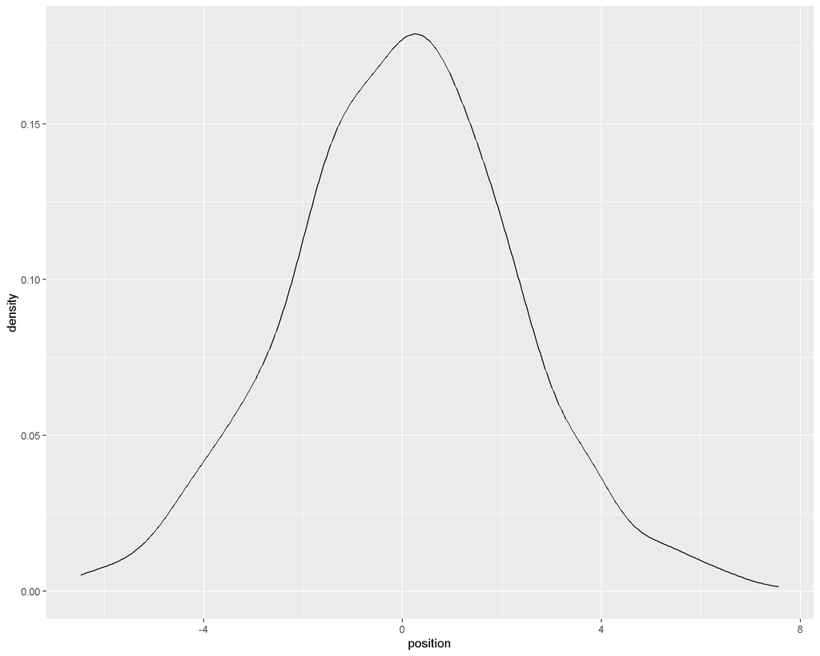

```r
ggplot(pos, aes(x=position)) +
  stat_density(geom="line") +
  spec
```

We can also show the progression along each step as in Figure 4.2.

```r
pos2 <- replicate(100, runif(16,-1,1)) %>% # note we take 16 steps per player now, not the sum of all steps
  as_tibble()
pos2
```

```
## # A tibble: 16 x 100
##          V1      V2      V3     V4      V5      V6      V7     V8       V9
##       <dbl>   <dbl>   <dbl>  <dbl>   <dbl>   <dbl>   <dbl>  <dbl>    <dbl>
##  1  0.263    0.247  -0.808   0.965 -0.124  -0.141   0.0932 -0.549 -0.132
##  2 -0.561    0.635   0.321   0.884  0.428   0.870  -0.582  -0.249  0.245
##  3 -0.643   -0.487  -0.380  -0.162 -0.446   0.331   0.941  -0.283  0.00397
##  4 -0.966    0.929  -0.301  -0.814 -0.481  -0.546  -0.201  -0.114  0.562
##  5  0.706   -0.818  -0.214  -0.782  0.534   0.506   0.607   0.385 -0.503
##  6 -0.0898   0.103  -0.0104  0.925 -0.223  -0.0704 -0.148   0.479  0.799
##  7 -0.719    0.287  -0.201  -0.555  0.747   0.0754 -0.870  -0.226 -0.0151
##  8  0.867   -0.449   0.136  -0.337 -0.452   0.288  -0.958  -0.301 -0.893
##  9  0.213    0.209   0.163   0.615  0.417   0.763   0.712   0.968  0.404
## 10  0.00252  0.361   0.0468  0.154  0.810   0.403   0.930  -0.739 -0.845
## 11  0.944   -0.693  -0.164   0.875 -0.845  -0.947  -0.945   0.631  0.860
## 12 -0.137   -0.600   0.968  -0.520  0.433  -0.185   0.391  -0.534  0.721
## 13 -0.0224  -0.853  -0.289   0.658 -0.764  -0.470  -0.774  -0.822  0.305
## 14  0.159    0.765  -0.824   0.813 -0.0130 -0.417  -0.333  -0.356  0.147
## 15 -0.543    0.0759  0.592   0.585  0.930  -0.416  -0.240   0.734 -0.928
## 16 -0.138    0.554  -0.677  -0.476  0.932   0.717   0.0491  0.398 -0.287
## # ... with 91 more variables: V10 <dbl>, V11 <dbl>, V12 <dbl>, V13 <dbl>,
## #   V14 <dbl>, V15 <dbl>, V16 <dbl>, V17 <dbl>, V18 <dbl>, V19 <dbl>,
## #   V20 <dbl>, V21 <dbl>, V22 <dbl>, V23 <dbl>, V24 <dbl>, V25 <dbl>,
## #   V26 <dbl>, V27 <dbl>, V28 <dbl>, V29 <dbl>, V30 <dbl>, V31 <dbl>,
## #   V32 <dbl>, V33 <dbl>, V34 <dbl>, V35 <dbl>, V36 <dbl>, V37 <dbl>,
## #   V38 <dbl>, V39 <dbl>, V40 <dbl>, V41 <dbl>, V42 <dbl>, V43 <dbl>,
## #   V44 <dbl>, V45 <dbl>, V46 <dbl>, V47 <dbl>, V48 <dbl>, V49 <dbl>,
## #   V50 <dbl>, V51 <dbl>, V52 <dbl>, V53 <dbl>, V54 <dbl>, V55 <dbl>,
## #   V56 <dbl>, V57 <dbl>, V58 <dbl>, V59 <dbl>, V60 <dbl>, V61 <dbl>,
## #   V62 <dbl>, V63 <dbl>, V64 <dbl>, V65 <dbl>, V66 <dbl>, V67 <dbl>,
## #   V68 <dbl>, V69 <dbl>, V70 <dbl>, V71 <dbl>, V72 <dbl>, V73 <dbl>,
## #   V74 <dbl>, V75 <dbl>, V76 <dbl>, V77 <dbl>, V78 <dbl>, V79 <dbl>,
## #   V80 <dbl>, V81 <dbl>, V82 <dbl>, V83 <dbl>, V84 <dbl>, V85 <dbl>,
## #   V86 <dbl>, V87 <dbl>, V88 <dbl>, V89 <dbl>, V90 <dbl>, V91 <dbl>,
## #   V92 <dbl>, V93 <dbl>, V94 <dbl>, V95 <dbl>, V96 <dbl>, V97 <dbl>,
## #   V98 <dbl>, V99 <dbl>, V100 <dbl>
```

Each step is a row, each player is a column

We’ll add a row for step zero and an index for each player, then pivot the table to long format

```r
pos2L <- pos2 %>%
  rbind(0,.) %>%
  mutate(step=0:16) %>%
  pivot_longer(cols=1:100,
               names_to="player",
               values_to="value") %>%
  group_by(player) %>%
  mutate(progress=cumsum(value)) %>%
  ungroup() %>%
  arrange(player)
pos2L
```

```
## # A tibble: 1,700 x 4
##     step player   value progress
##    <int> <chr>    <dbl>    <dbl>
##  1     0 V1      0         0
##  2     1 V1      0.263     0.263
##  3     2 V1     -0.561    -0.298
##  4     3 V1     -0.643    -0.941
##  5     4 V1     -0.966    -1.91
##  6     5 V1      0.706    -1.20
##  7     6 V1     -0.0898   -1.29
##  8     7 V1     -0.719    -2.01
##  9     8 V1      0.867    -1.14
## 10     9 V1      0.213    -0.929
## # ... with 1,690 more rows
```

Note that when each player was a column, the step value was implicit in each row number. That information was lost when we pivoted the table to long format, so we created the ‘step’ variable to re-capture the information of which case belonged to which step, for each player.

Let’s also track the mean of all players at each step.

```r
byStep <- pos2L %>%
  group_by(step) %>%
  summarize(progress=mean(progress)) %>%
  mutate(player="stepMean",
         value=NA)
byStep
```

```
## # A tibble: 17 x 4
##     step progress player   value
##    <int>    <dbl> <chr>    <lgl>
##  1     0   0      stepMean NA
##  2     1  -0.0260 stepMean NA
##  3     2  -0.107  stepMean NA
##  4     3  -0.249  stepMean NA
##  5     4  -0.244  stepMean NA
##  6     5  -0.255  stepMean NA
##  7     6  -0.222  stepMean NA
##  8     7  -0.228  stepMean NA
##  9     8  -0.244  stepMean NA
## 10     9  -0.156  stepMean NA
## 11    10  -0.210  stepMean NA
## 12    11  -0.253  stepMean NA
## 13    12  -0.268  stepMean NA
## 14    13  -0.256  stepMean NA
## 15    14  -0.206  stepMean NA
## 16    15  -0.141  stepMean NA
## 17    16  -0.188  stepMean NA
```

```r
#pos2L <- pos2L %>%
#  left_join(byStep)
```

Now we can graph the top panel of Figure 4.2

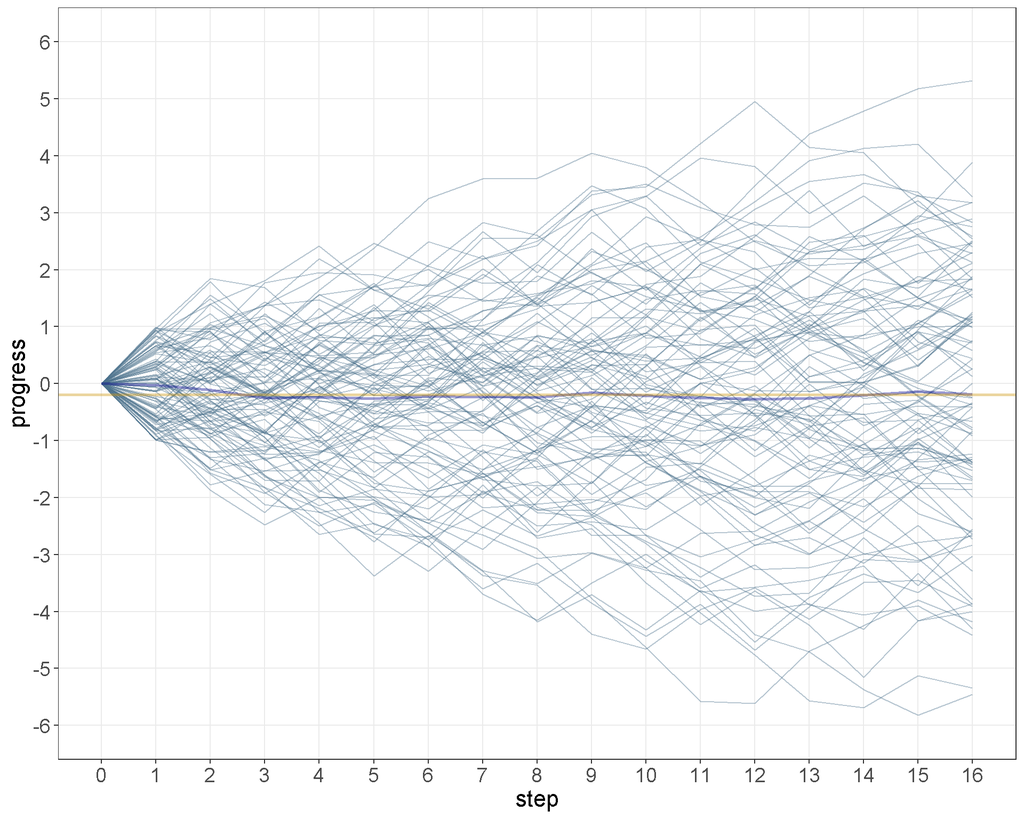

```r
ggplot(pos2L, aes(x=step, y=progress, group=player)) +
  geom_line(color="skyblue4", alpha=.4, size=.5) +
  geom_line(aes(step, progress), color="darkblue", data=byStep, size=1, alpha=.4) +
  #gghighlight(player=="stepMean") +
  scale_x_continuous(breaks=0:16) +
  scale_y_continuous(limits=c(-6,6),
                     breaks=-6:6) +
  #stat_smooth(aes(progress), color="pink", alpha=.8, se=F) +
  geom_hline(yintercept=mean(pos2L$progress), color="darkgoldenrod3", size=1, alpha=.4)
```